# Matplotlib Tutorial

# Matplotlib Line

# Linestyle

You can use the keyword argument linestyle, or shorter ls, to change the style of the plotted line:

Use a dotted line:

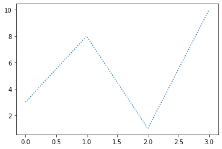

```python
import matplotlib.pyplot as plt
import numpy as np

ypoints = np.array([3, 8, 1, 10])

plt.plot(ypoints, linestyle = 'dotted')
plt.show()
```

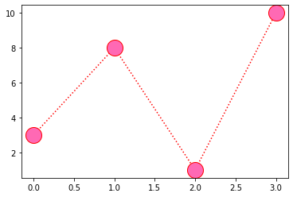

```python
import matplotlib.pyplot as plt
import numpy as np

ypoints = np.array([3, 8, 1, 10])

plt.plot(ypoints,'o',c='red', linestyle = 'dotted',ms=20,mec = 'r', mfc = 'hotpink')
plt.show()
```

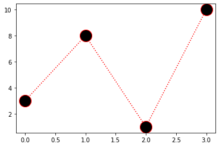

```python
import matplotlib.pyplot as plt
import numpy as np

ypoints = np.array([3, 8, 1, 10])

plt.plot(ypoints,'o',c='red',ms=20, linestyle = 'dotted',mec='r',mfc='k')
plt.show()
```

Use a dashed line:

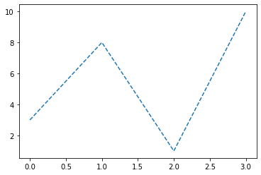

```python
import matplotlib.pyplot as plt
import numpy as np

ypoints = np.array([3, 8, 1, 10])

plt.plot(ypoints, linestyle = 'dashed')

plt.show()
```

# Shorter Syntax

The line style can be written in a shorter syntax:

linestyle can be written as ls.

dotted can be written as :.

dashed can be written as --.

Shorter syntax:

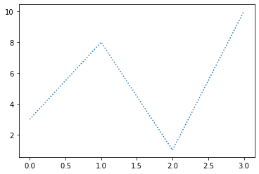

```python
import matplotlib.pyplot as plt
import numpy as np

ypoints = np.array([3, 8, 1, 10])

plt.plot(ypoints, ls = ':')

plt.show()
```

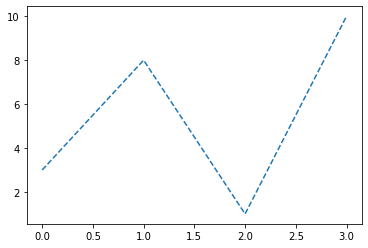

```python
import matplotlib.pyplot as plt
import numpy as np

ypoints = np.array([3, 8, 1, 10])

plt.plot(ypoints, ls = '--')

plt.show()
```

# Line Styles

You can choose any of these styles:

Style Or

'solid' (default) '-' 'dotted' ':' 'dashed' '--'  
'dashdot' '-.'  
'None' '' or ' '

# Line Color

You can use the keyword argument color or the shorter c to set the color of the line:

Set the line color to red:

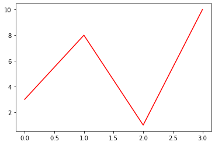

```python
import matplotlib.pyplot as plt
import numpy as np

ypoints = np.array([3, 8, 1, 10])

plt.plot(ypoints, color = 'r')
plt.show()
```

Plot with a beautiful green line:

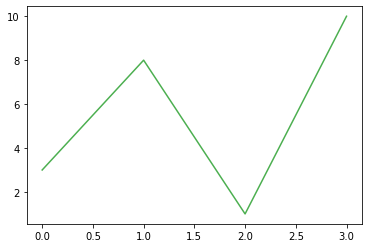

```python
import matplotlib.pyplot as plt
import numpy as np

ypoints = np.array([3, 8, 1, 10])

plt.plot(ypoints, c = '#4CAF50')

plt.show()
```

Plot with the color named "hotpink":

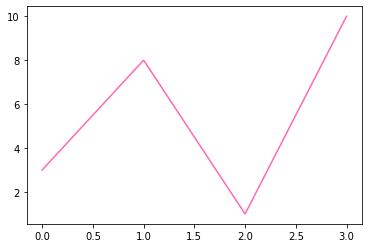

```python
import matplotlib.pyplot as plt
import numpy as np

ypoints = np.array([3, 8, 1, 10])

plt.plot(ypoints, c = 'hotpink')

plt.show()
```

# Line Width

You can use the keyword argument linewidth or the shorter lw to change the width of the line.

The value is a floating number, in points:

Plot with a 20.5pt wide line:

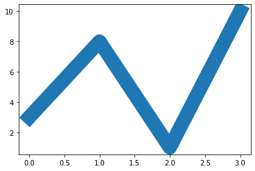

```python
import matplotlib.pyplot as plt
import numpy as np

ypoints = np.array([3, 8, 1, 10])

plt.plot(ypoints, linewidth = '20.5')
plt.show()
```

# Multiple Lines

You can plot as many lines as you like by simply adding more plt.plot() functions:

Draw two lines by specifying a plt.plot() function for each line:

```python
import matplotlib.pyplot as plt
import numpy as np

y1 = np.array([3, 8, 1, 10])
y2 = np.array([6, 2, 7, 11])

plt.plot(y1)
plt.plot(y2)

plt.show()
```

[output not shown]

You can also plot many lines by adding the points for the x- and y-axis for each line in the same plt.plot() function.

(In the examples above we only specified the points on the y-axis, meaning that the points on the x-axis got the the default values (0, 1, 2, 3).)

The x- and y- values come in pairs:

Draw two lines by specifiyng the x- and y-point values for both lines:

```python
import matplotlib.pyplot as plt
import numpy as np

x1 = np.array([0, 1, 2, 3])
y1 = np.array([3, 8, 1, 10])
x2 = np.array([0, 1, 2, 3])
y2 = np.array([6, 2, 7, 11])

plt.plot(x1, y1, x2, y2)
plt.show()
```

[output not shown]

```python
import matplotlib.pyplot as plt
import numpy as np

x1 = np.array([0, 1, 2, 3])
y1 = np.array([3, 8, 1, 10])
x2 = np.array([0, 1, 2, 3])
y2 = np.array([6, 2, 7, 11])

plt.plot(x1, y1)
plt.plot(x2,y2)

plt.show()
```

[output not shown]

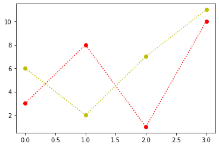

```python
import matplotlib.pyplot as plt
import numpy as np

x1 = np.array([0, 1, 2, 3])
y1 = np.array([3, 8, 1, 10])
x2 = np.array([0, 1, 2, 3])
y2 = np.array([6, 2, 7, 11])

plt.plot(x1, y1,'o:r')
plt.plot(x2,y2,'o:y')
plt.show()
```

# Matplotlib Labels and Title

# Create Labels for a Plot

With Pyplot, you can use the xlabel() and ylabel() functions to set a label for the x- and y-axis.

Add labels to the x- and y-axis:

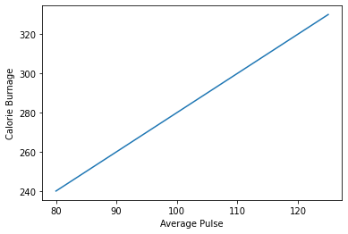

```python
import numpy as np
import matplotlib.pyplot as plt

x = np.array([80, 85, 90, 95, 100, 105, 110, 115, 120, 125])
y = np.array([240, 250, 260, 270, 280, 290, 300, 310, 320, 330])

plt.plot(x, y)

plt.xlabel("Average Pulse")
plt.ylabel("Calorie Burnage")

plt.show()
```

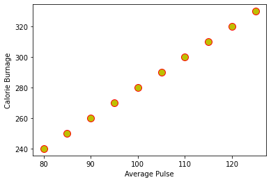

```python
import numpy as np
import matplotlib.pyplot as plt

x = np.array([80, 85, 90, 95, 100, 105, 110, 115, 120, 125])
y = np.array([240, 250, 260, 270, 280, 290, 300, 310, 320, 330])

plt.plot(x, y,'or',ms=10,mec='r',mfc='y')

plt.xlabel("Average Pulse")
plt.ylabel("Calorie Burnage")

plt.show()
```

# Create a Title for a Plot

With Pyplot, you can use the title() function to set a title for the plot.

Add a plot title and labels for the x- and y-axis:

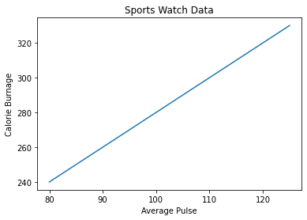

```python
import numpy as np
import matplotlib.pyplot as plt

x = np.array([80, 85, 90, 95, 100, 105, 110, 115, 120, 125])
y = np.array([240, 250, 260, 270, 280, 290, 300, 310, 320, 330])

plt.plot(x, y)

plt.title("Sports Watch Data")
plt.xlabel("Average Pulse")
plt.ylabel("Calorie Burnage")

plt.show()
```

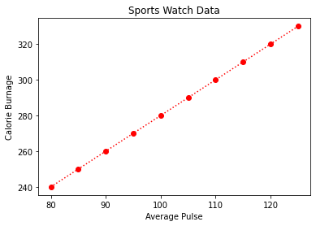

```python
import numpy as np
import matplotlib.pyplot as plt

x = np.array([80, 85, 90, 95, 100, 105, 110, 115, 120, 125])
y = np.array([240, 250, 260, 270, 280, 290, 300, 310, 320, 330])

plt.plot(x, y,'o:r')

plt.title("Sports Watch Data")
plt.xlabel("Average Pulse")
plt.ylabel("Calorie Burnage")

plt.show()
```

# Set Font Properties for Title and Labels

You can use the fontdict parameter in xlabel(), ylabel(), and title() to set font properties for the title and labels.

Set font properties for the title and labels:

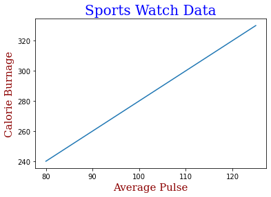

```python
import numpy as np
import matplotlib.pyplot as plt

x = np.array([80, 85, 90, 95, 100, 105, 110, 115, 120, 125])
y = np.array([240, 250, 260, 270, 280, 290, 300, 310, 320, 330])

font1 = {'family':'serif','color':'blue','size':20}
font2 = {'family':'serif','color':'darkred','size':15}

plt.title("Sports Watch Data", fontdict = font1)
plt.xlabel("Average Pulse", fontdict = font2)
plt.ylabel("Calorie Burnage", fontdict = font2)

plt.plot(x, y)
plt.show()
```

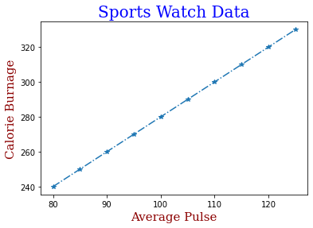

```python
import numpy as np
import matplotlib.pyplot as plt

x = np.array([80, 85, 90, 95, 100, 105, 110, 115, 120, 125])
y = np.array([240, 250, 260, 270, 280, 290, 300, 310, 320, 330])

font1 = {'family':'serif','color':'blue','size':20}
font2 = {'family':'serif','color':'darkred','size':15}

plt.title("Sports Watch Data", fontdict = font1)
plt.xlabel("Average Pulse", fontdict = font2)
plt.ylabel("Calorie Burnage", fontdict = font2)

plt.plot(x, y,'*-.')
plt.show()
```

# Position the Title

You can use the loc parameter in title() to position the title.

Legal values are: 'left', 'right', and 'center'. Default value is 'center'.

Position the title to the left:

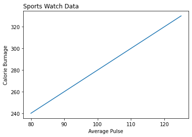

```python
import numpy as np
import matplotlib.pyplot as plt

x = np.array([80, 85, 90, 95, 100, 105, 110, 115, 120, 125])
y = np.array([240, 250, 260, 270, 280, 290, 300, 310, 320, 330])

plt.title("Sports Watch Data", loc = 'left')
plt.xlabel("Average Pulse")
plt.ylabel("Calorie Burnage")

plt.plot(x, y)
plt.show()
```

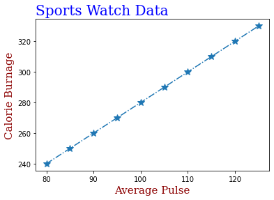

```python
import numpy as np
import matplotlib.pyplot as plt

x = np.array([80, 85, 90, 95, 100, 105, 110, 115, 120, 125])
y = np.array([240, 250, 260, 270, 280, 290, 300, 310, 320, 330])

font1 = {'family':'serif','color':'blue','size':20}
font2 = {'family':'serif','color':'darkred','size':15}

plt.title("Sports Watch Data",loc='left', fontdict = font1)
plt.xlabel("Average Pulse", fontdict = font2)
plt.ylabel("Calorie Burnage", fontdict = font2)

plt.plot(x, y,'*-.',ms=10)
plt.show()
```

# Matplotlib Adding Grid Lines

# Add Grid Lines to a Plot

With Pyplot, you can use the grid() function to add grid lines to the plot.

Add grid lines to the plot:

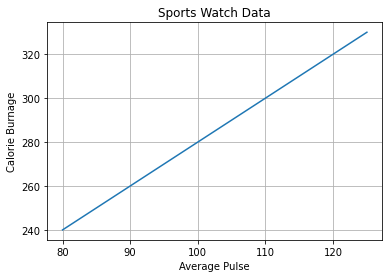

```python
import numpy as np
import matplotlib.pyplot as plt

x = np.array([80, 85, 90, 95, 100, 105, 110, 115, 120, 125])
y = np.array([240, 250, 260, 270, 280, 290, 300, 310, 320, 330])

plt.title("Sports Watch Data")
plt.xlabel("Average Pulse")
plt.ylabel("Calorie Burnage")

plt.plot(x, y)

plt.grid()

plt.show()
```

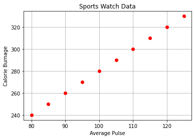

```python
import numpy as np
import matplotlib.pyplot as plt

x = np.array([80, 85, 90, 95, 100, 105, 110, 115, 120, 125])
y = np.array([240, 250, 260, 270, 280, 290, 300, 310, 320, 330])

plt.title("Sports Watch Data")
plt.xlabel("Average Pulse")
plt.ylabel("Calorie Burnage")

plt.plot(x, y,'or')

plt.grid()

plt.show()
```

# Specify Which Grid Lines to Display

You can use the axis parameter in the grid() function to specify which grid lines to display.

Legal values are: 'x', 'y', and 'both'. Default value is 'both'.

Display only grid lines for the x-axis:

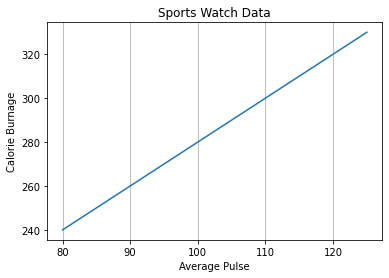

```python
import numpy as np
import matplotlib.pyplot as plt

x = np.array([80, 85, 90, 95, 100, 105, 110, 115, 120, 125])
y = np.array([240, 250, 260, 270, 280, 290, 300, 310, 320, 330])

plt.title("Sports Watch Data")
plt.xlabel("Average Pulse")
plt.ylabel("Calorie Burnage")

plt.plot(x, y)

plt.grid(axis = 'x')

plt.show()
```

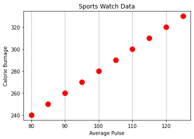

```python
import numpy as np
import matplotlib.pyplot as plt

x = np.array([80, 85, 90, 95, 100, 105, 110, 115, 120, 125])
y = np.array([240, 250, 260, 270, 280, 290, 300, 310, 320, 330])

plt.title("Sports Watch Data")
plt.xlabel("Average Pulse")
plt.ylabel("Calorie Burnage")

plt.plot(x, y,'or',ms=10)

plt.grid(axis = 'x')

plt.show()
```

Display only grid lines for the y-axis:

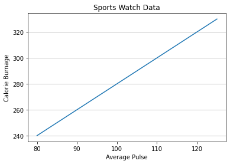

```python
import numpy as np
import matplotlib.pyplot as plt

x = np.array([80, 85, 90, 95, 100, 105, 110, 115, 120, 125])
y = np.array([240, 250, 260, 270, 280, 290, 300, 310, 320, 330])

plt.title("Sports Watch Data")
plt.xlabel("Average Pulse")
plt.ylabel("Calorie Burnage")

plt.plot(x, y)

plt.grid(axis = 'y')

plt.show()
```

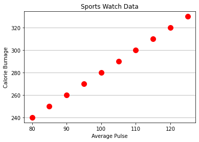

```python
import numpy as np
import matplotlib.pyplot as plt

x = np.array([80, 85, 90, 95, 100, 105, 110, 115, 120, 125])
y = np.array([240, 250, 260, 270, 280, 290, 300, 310, 320, 330])

plt.title("Sports Watch Data")
plt.xlabel("Average Pulse")
plt.ylabel("Calorie Burnage")

plt.plot(x, y,'or',ms=10)

plt.grid(axis = 'y')

plt.show()
```

# Set Line Properties for the Grid

You can also set the line properties of the grid, like this: grid(color = 'color', linestyle = 'linestyle', linewidth = number).

Set the line properties of the grid:

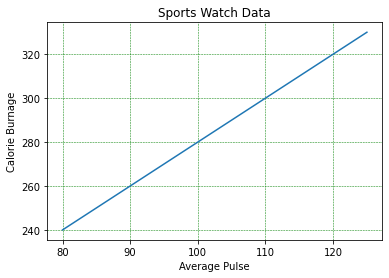

```python
import numpy as np
import matplotlib.pyplot as plt

x = np.array([80, 85, 90, 95, 100, 105, 110, 115, 120, 125])
y = np.array([240, 250, 260, 270, 280, 290, 300, 310, 320, 330])

plt.title("Sports Watch Data")
plt.xlabel("Average Pulse")
plt.ylabel("Calorie Burnage")

plt.plot(x, y)

plt.grid(color = 'green', linestyle = '--', linewidth = 0.5)

plt.show()
```

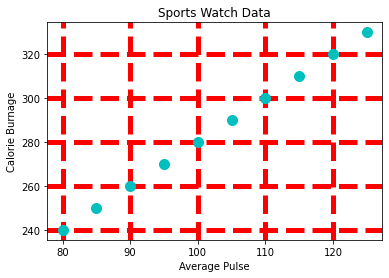

```python
import numpy as np
import matplotlib.pyplot as plt

x = np.array([80, 85, 90, 95, 100, 105, 110, 115, 120, 125])
y = np.array([240, 250, 260, 270, 280, 290, 300, 310, 320, 330])

plt.title("Sports Watch Data")
plt.xlabel("Average Pulse")
plt.ylabel("Calorie Burnage")

plt.plot(x, y,'oc',ms=10)

plt.grid(color = 'red', linestyle = '--', linewidth = 5)

plt.show()
```

# Matplotlib Subplots

# Display Multiple Plots

With the subplots() function you can draw multiple plots in one figure:

Draw 2 plots:

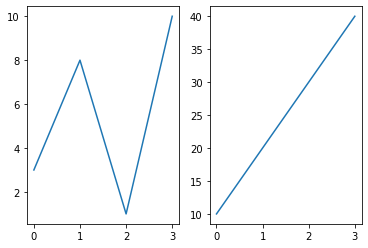

```python
import matplotlib.pyplot as plt
import numpy as np

#plot 1:
x = np.array([0, 1, 2, 3])
y = np.array([3, 8, 1, 10])

plt.subplot(1, 2, 1)
plt.plot(x,y)

#plot 2:
x = np.array([0, 1, 2, 3])
y = np.array([10, 20, 30, 40])

plt.subplot(1, 2, 2)
plt.plot(x,y)

plt.show()
```

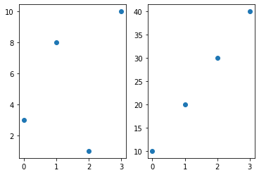

```python
import matplotlib.pyplot as plt
import numpy as np

#plot 1:
x = np.array([0, 1, 2, 3])
y = np.array([3, 8, 1, 10])

plt.subplot(1, 2, 1)
plt.plot(x,y,'o')

#plot 2:
x = np.array([0, 1, 2, 3])
y = np.array([10, 20, 30, 40])

plt.subplot(1, 2, 2)
plt.plot(x,y,'o')

plt.show()
```

# The subplots() Function

The subplots() function takes three arguments that describes the layout of the figure.

The layout is organized in rows and columns, which are represented by the first and second argument.

The third argument represents the index of the current plot.

plt.subplot(1, 2, 1)

the figure has 1 row, 2 columns, and this plot is the first plot.

plt.subplot(1, 2, 2)

the figure has 1 row, 2 columns, and this plot is the second plot.

So, if we want a figure with 2 rows an 1 column (meaning that the two plots will be displayed on top of each other instead of side-by-side), we can write the syntax like this:

Draw 2 plots on top of each other:

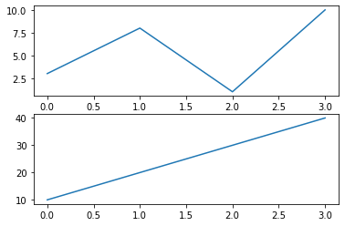

```python
import matplotlib.pyplot as plt
import numpy as np

#plot 1:
x = np.array([0, 1, 2, 3])
y = np.array([3, 8, 1, 10])

plt.subplot(2, 1, 1)
plt.plot(x,y)

#plot 2:
x = np.array([0, 1, 2, 3])
y = np.array([10, 20, 30, 40])

plt.subplot(2, 1, 2)
plt.plot(x,y)

plt.show()
```

Draw 6 plots:

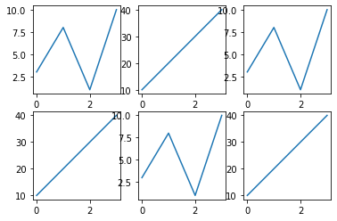

```python
import matplotlib.pyplot as plt
import numpy as np

x = np.array([0, 1, 2, 3])
y = np.array([3, 8, 1, 10])

plt.subplot(2, 3, 1)
plt.plot(x,y)

x = np.array([0, 1, 2, 3])
y = np.array([10, 20, 30, 40])

plt.subplot(2, 3, 2)
plt.plot(x,y)

x = np.array([0, 1, 2, 3])
y = np.array([3, 8, 1, 10])

plt.subplot(2, 3, 3)
plt.plot(x,y)

x = np.array([0, 1, 2, 3])
y = np.array([10, 20, 30, 40])

plt.subplot(2, 3, 4)
plt.plot(x,y)

x = np.array([0, 1, 2, 3])
y = np.array([3, 8, 1, 10])

plt.subplot(2, 3, 5)
plt.plot(x,y)

x = np.array([0, 1, 2, 3])
y = np.array([10, 20, 30, 40])

plt.subplot(2, 3, 6)
plt.plot(x,y)

plt.show()
```

# Title

You can add a title to each plot with the title() function:

2 plots, with titles:

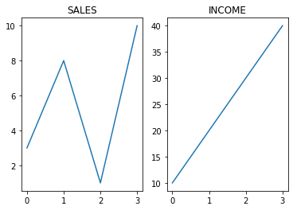

```python
import matplotlib.pyplot as plt
import numpy as np

#plot 1:
x = np.array([0, 1, 2, 3])
y = np.array([3, 8, 1, 10])

plt.subplot(1, 2, 1)
plt.plot(x,y)
plt.title("SALES")

#plot 2:
x = np.array([0, 1, 2, 3])
y = np.array([10, 20, 30, 40])

plt.subplot(1, 2, 2)
plt.plot(x,y)
plt.title("INCOME")

plt.show()
```

# Super Title

You can add a title to the entire figure with the suptitle() function:

Add a title for the entire figure:

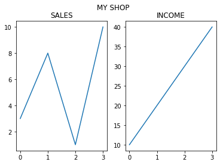

```python
import matplotlib.pyplot as plt
import numpy as np

#plot 1:
x = np.array([0, 1, 2, 3])
y = np.array([3, 8, 1, 10])

plt.subplot(1, 2, 1)
plt.plot(x,y)
plt.title("SALES")

#plot 2:
x = np.array([0, 1, 2, 3])
y = np.array([10, 20, 30, 40])

plt.subplot(1, 2, 2)
plt.plot(x,y)
plt.title("INCOME")

plt.suptitle("MY SHOP")
plt.show()
```

# Matplotlib Scatter

# Creating Scatter Plots

With Pyplot, you can use the scatter() function to draw a scatter plot.

The scatter() function plots one dot for each observation. It needs two arrays of the same length, one for the values of the x-axis, and one for values on the y-axis:

A simple scatter plot:

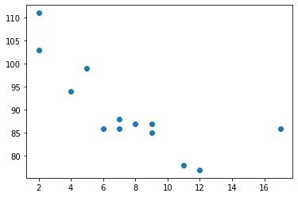

```python
import matplotlib.pyplot as plt
import numpy as np

x = np.array([5,7,8,7,2,17,2,9,4,11,12,9,6])
y = np.array([99,86,87,88,111,86,103,87,94,78,77,85,86])

plt.scatter(x, y)#must be x,y
plt.show()
```

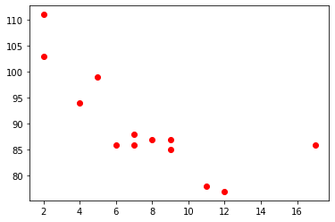

```python
import matplotlib.pyplot as plt
import numpy as np

x = np.array([5,7,8,7,2,17,2,9,4,11,12,9,6])
y = np.array([99,86,87,88,111,86,103,87,94,78,77,85,86])

plt.scatter(x, y,c='r')
plt.show()
```

The observation in the example above is the result of 13 cars passing by.

The X-axis shows how old the car is.

The Y-axis shows the speed of the car when it passes.

Are there any relationships between the observations?

It seems that the newer the car, the faster it drives, but that could be a coincidence, after all we only registered 13 cars.

# Compare Plots

In the example above, there seems to be a relationship between speed and age, but what if we plot the observations from another day as well? Will the scatter plot tell us something else?

Draw two plots on the same figure:

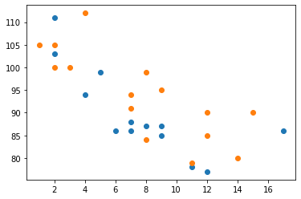

```python
import matplotlib.pyplot as plt
import numpy as np

#day one, the age and speed of 13 cars:
x = np.array([5,7,8,7,2,17,2,9,4,11,12,9,6])
y = np.array([99,86,87,88,111,86,103,87,94,78,77,85,86])
plt.scatter(x, y)

#day two, the age and speed of 15 cars:
x = np.array([2,2,8,1,15,8,12,9,7,3,11,4,7,14,12])
y = np.array([100,105,84,105,90,99,90,95,94,100,79,112,91,80,85])
plt.scatter(x, y)

plt.show()
```

Note: The two plots are plotted with two different colors, by default blue and orange, you will learn how to change colors later in this chapter.

By comparing the two plots, I think it is safe to say that they both gives us the same conclusion: the newer the car, the faster it drives.

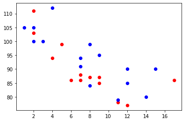

```python
import matplotlib.pyplot as plt
import numpy as np

#day one, the age and speed of 13 cars:
x = np.array([5,7,8,7,2,17,2,9,4,11,12,9,6])
y = np.array([99,86,87,88,111,86,103,87,94,78,77,85,86])
plt.scatter(x, y,c='r')

#day two, the age and speed of 15 cars:
x = np.array([2,2,8,1,15,8,12,9,7,3,11,4,7,14,12])
y = np.array([100,105,84,105,90,99,90,95,94,100,79,112,91,80,85])
plt.scatter(x, y,c='b')

plt.show()
```

# Colors

You can set your own color for each scatter plot with the color or the c argument:

Set your own color of the markers:

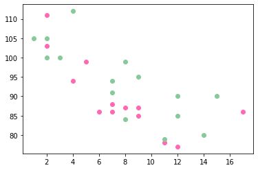

```python
import matplotlib.pyplot as plt
import numpy as np

x = np.array([5,7,8,7,2,17,2,9,4,11,12,9,6])
y = np.array([99,86,87,88,111,86,103,87,94,78,77,85,86])
plt.scatter(x, y, color = 'hotpink')

x = np.array([2,2,8,1,15,8,12,9,7,3,11,4,7,14,12])
y = np.array([100,105,84,105,90,99,90,95,94,100,79,112,91,80,85])
plt.scatter(x, y, color = '#88c999')

plt.show()
```

# Color Each Dot

You can even set a specific color for each dot by using an array of colors as value for the c argument:

Note: You cannot use the color argument for this, only the c argument.

Set your own color of the markers:

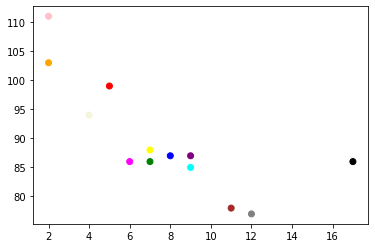

```python
import matplotlib.pyplot as plt
import numpy as np

x = np.array([5,7,8,7,2,17,2,9,4,11,12,9,6])
y = np.array([99,86,87,88,111,86,103,87,94,78,77,85,86])
colors = np.array(["red","green","blue","yellow","pink","black","orange","purple","beige","brown","gray","cyan","magenta"])

plt.scatter(x, y, c=colors)

plt.show()
```

# ColorMap

The Matplotlib module has a number of available colormaps.

A colormap is like a list of colors, where each color has a value that ranges from 0 to 100.

# How to Use the ColorMap

You can specify the colormap with the keyword argument cmap with the value of the colormap, in this case 'viridis' which is one of the built-in colormaps available in Matplotlib.

In addition you have to create an array with values (from 0 to 100), one value for each of the point in the scatter plot

Create a color array, and specify a colormap in the scatter plot:

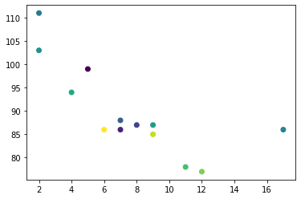

```python
import matplotlib.pyplot as plt
import numpy as np

x = np.array([5,7,8,7,2,17,2,9,4,11,12,9,6])
y = np.array([99,86,87,88,111,86,103,87,94,78,77,85,86])
colors = np.array([0, 10, 20, 30, 40, 45, 50, 55, 60, 70, 80, 90, 100])

plt.scatter(x, y, c=colors, cmap='viridis')

plt.show()
```

You can include the colormap in the drawing by including the plt.colorbar() statement:

Include the actual colormap:

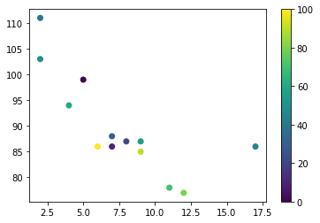

```python
import matplotlib.pyplot as plt
import numpy as np

x = np.array([5,7,8,7,2,17,2,9,4,11,12,9,6])
y = np.array([99,86,87,88,111,86,103,87,94,78,77,85,86])
colors = np.array([0, 10, 20, 30, 40, 45, 50, 55, 60, 70, 80, 90, 100])

plt.scatter(x, y, c=colors, cmap='viridis')

plt.colorbar()

plt.show()
```

# Available ColorMaps

You can choose any of the built-in colormaps:

Name Reverse

Accent Accent_r Blues Blues_r  
BrBG BrBG_r  
BuGn BuGn_r  
BuPu BuPu_r  
CMRmap CMRmap_r  
Dark2 Dark2_r GnBu GnBu_r  
Greens Greens_r  
Greys Greys_r OrRd OrRd_r  
Oranges Oranges_r  
PRGn PRGn_r  
Paired Paired_r  
Pastel1 Pastel1_r  
Pastel2 Pastel2_r  
PiYG PiYG_r  
PuBu PuBu_r  
PuBuGn PuBuGn_r  
PuOr PuOr_r  
PuRd PuRd_r  
Purples Purples_r  
RdBu RdBu_r  
RdGy RdGy_r  
RdPu RdPu_r  
RdYlBu RdYlBu_r  
RdYlGn RdYlGn_r  
Reds Reds_r  
Set1 Set1_r  
Set2 Set2_r  
Set3 Set3_r  
Spectral Spectral_r  
Wistia Wistia_r  
YlGn YlGn_r  
YlGnBu YlGnBu_r  
YlOrBr YlOrBr_r  
YlOrRd YlOrRd_r  
afmhot afmhot_r  
autumn autumn_r  
binary binary_r  
bone bone_r  
brg brg_r  
bwr bwr_r  
cividis cividis_r  
cool cool_r  
coolwarm coolwarm_r  
copper copper_r  
cubehelix cubehelix_r flag flag_r  
gist_earth gist_earth_r  
gist_gray gist_gray_r gist_heat gist_heat_r gist_ncar gist_ncar_r gist_rainbow gist_rainbow_r  
gist_stern gist_stern_r  
gist_yarg gist_yarg_r gnuplot gnuplot_r  
gnuplot2 gnuplot2_r  
gray gray_r  
hot hot_r  
hsv hsv_r  
inferno inferno_r  
jet jet_r  
magma magma_r nipy_spectral nipy_spectral_r ocean ocean_r pink pink_r  
plasma plasma_r  
prism prism_r rainbow rainbow_r  
seismic seismic_r  
spring spring_r  
summer summer_r  
tab10 tab10_r tab20 tab20_r tab20b tab20b_r  
tab20c tab20c_r  
terrain terrain_r  
twilight twilight_r  
twilight_shifted twilight_shifted_r  
viridis viridis_r  
winter winter_r

# Accent

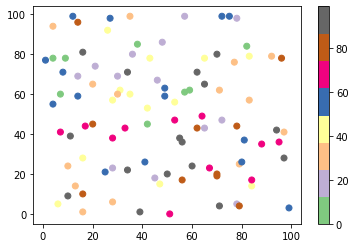

```python
import matplotlib.pyplot as plt
import numpy as np

x = np.random.randint(100, size=(100))
y = np.random.randint(100, size=(100))
colors = np.random.randint(100, size=(100))

plt.scatter(x, y, c=colors, cmap='Accent')

plt.colorbar()

plt.show()
```

# Accent_r

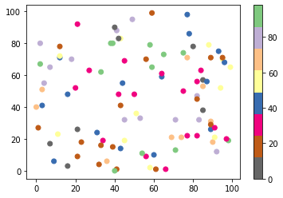

```python
import matplotlib.pyplot as plt
import numpy as np

x = np.random.randint(100, size=(100))
y = np.random.randint(100, size=(100))
colors = np.random.randint(100, size=(100))

plt.scatter(x, y, c=colors, cmap='Accent_r')

plt.colorbar()

plt.show()
```

# Size

You can change the size of the dots with the s argument.

Just like colors, make sure the array for sizes has the same length as the arrays for the x- and y-axis:

Set your own size for the markers:

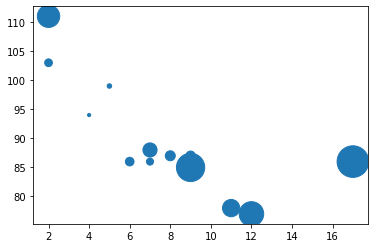

```python
import matplotlib.pyplot as plt
import numpy as np

x = np.array([5,7,8,7,2,17,2,9,4,11,12,9,6])
y = np.array([99,86,87,88,111,86,103,87,94,78,77,85,86])
sizes = np.array([20,50,100,200,500,1000,60,90,10,300,600,800,75])

plt.scatter(x, y, s=sizes)

plt.show()
```

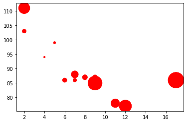

```python
import matplotlib.pyplot as plt
import numpy as np

x = np.array([5,7,8,7,2,17,2,9,4,11,12,9,6])
y = np.array([99,86,87,88,111,86,103,87,94,78,77,85,86])
sizes = np.array([20,50,100,200,500,1000,60,90,10,300,600,800,75])

plt.scatter(x, y,c='r', s=sizes)

plt.show()
```

# Alpha

You can adjust the transparency of the dots with the alpha argument.

Just like colors, make sure the array for sizes has the same length as the arrays for the x- and y-axis:

Set your own size for the markers:

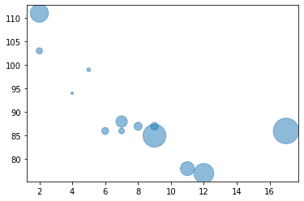

```python
import matplotlib.pyplot as plt
import numpy as np

x = np.array([5,7,8,7,2,17,2,9,4,11,12,9,6])
y = np.array([99,86,87,88,111,86,103,87,94,78,77,85,86])
sizes = np.array([20,50,100,200,500,1000,60,90,10,300,600,800,75])

plt.scatter(x, y, s=sizes, alpha=0.5)

plt.show()
```

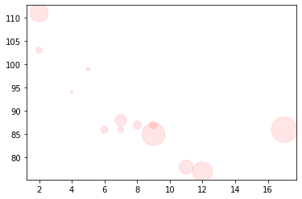

```python
import matplotlib.pyplot as plt
import numpy as np

x = np.array([5,7,8,7,2,17,2,9,4,11,12,9,6])
y = np.array([99,86,87,88,111,86,103,87,94,78,77,85,86])
sizes = np.array([20,50,100,200,500,1000,60,90,10,300,600,800,75])

plt.scatter(x,y,s=sizes,c='r',alpha=0.1)
```

# Combine Color Size and Alpha

You can combine a colormap with different sizes on the dots. This is best visualized if the dots are transparent:

Create random arrays with 100 values for x-points, y-points, colors and sizes:

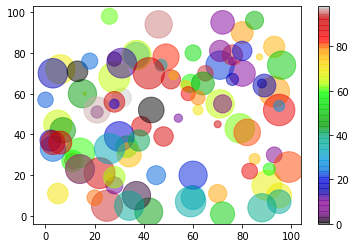

```python
import matplotlib.pyplot as plt
import numpy as np

x = np.random.randint(100, size=(100))
y = np.random.randint(100, size=(100))
colors = np.random.randint(100, size=(100))
sizes = 10 * np.random.randint(100, size=(100))

plt.scatter(x, y, c=colors, s=sizes, alpha=0.5, cmap='nipy_spectral')

plt.colorbar()

plt.show()
```

# Matplotlib Bars

# Creating Bars

With Pyplot, you can use the bar() function to draw bar graphs:

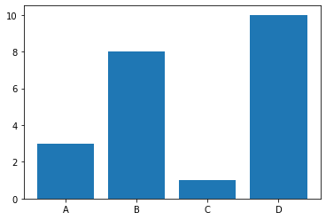

```python
import matplotlib.pyplot as plt
import numpy as np

x = np.array(["A", "B", "C", "D"])
y = np.array([3, 8, 1, 10])

plt.bar(x,y)
plt.show()
```

The bar() function takes arguments that describes the layout of the bars.

The categories and their values represented by the first and second argument as arrays.

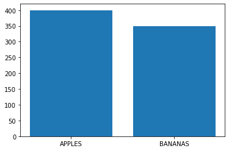

```python
import matplotlib.pyplot as plt
import numpy as np

x = ["APPLES", "BANANAS"]
y = [400, 350]

plt.bar(x, y)
plt.show()
```

# Horizontal Bars

If you want the bars to be displayed horizontally instead of vertically, use the barh() function:

Draw 4 horizontal bars:

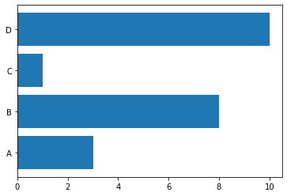

```python
import matplotlib.pyplot as plt
import numpy as np

x = np.array(["A", "B", "C", "D"])
y = np.array([3, 8, 1, 10])

plt.barh(x, y)
plt.show()
```

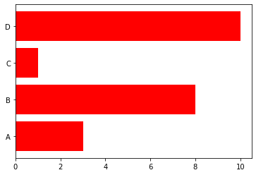

```python
import matplotlib.pyplot as plt
import numpy as np

x = np.array(["A", "B", "C", "D"])
y = np.array([3, 8, 1, 10])

plt.barh(x, y,color='r')
plt.show()
```

# Bar Color

The bar() and barh() takes the keyword argument color to set the color of the bars:

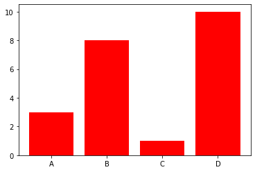

```python
import matplotlib.pyplot as plt
import numpy as np

x = np.array(["A", "B", "C", "D"])
y = np.array([3, 8, 1, 10])

plt.bar(x, y, color = "red")
plt.show()
```

Draw 4 "hot pink" bars:

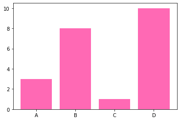

```python
import matplotlib.pyplot as plt
import numpy as np

x = np.array(["A", "B", "C", "D"])
y = np.array([3, 8, 1, 10])

plt.bar(x, y, color = "hotpink")
plt.show()
```

# Color Hex

Draw 4 bars with a beautiful green color:

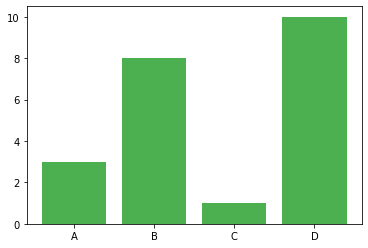

```python
import matplotlib.pyplot as plt
import numpy as np

x = np.array(["A", "B", "C", "D"])
y = np.array([3, 8, 1, 10])

plt.bar(x, y, color = "#4CAF50")
plt.show()
```

# Bar Width

The bar() takes the keyword argument width to set the width of the bars:

Draw 4 very thin bars:

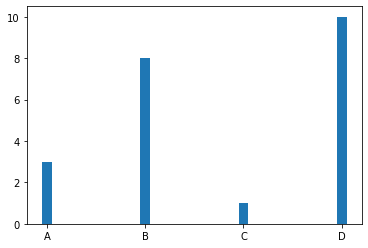

```python
import matplotlib.pyplot as plt
import numpy as np

x = np.array(["A", "B", "C", "D"])
y = np.array([3, 8, 1, 10])

plt.bar(x, y, width = 0.1)
plt.show()
```

The default width value is 0.8

Note: For horizontal bars, use height instead of width.

# Bar Height

The barh() takes the keyword argument height to set the height of the bars:

Draw 4 very thin bars:

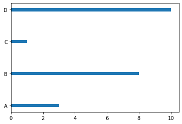

```python
import matplotlib.pyplot as plt
import numpy as np

x = np.array(["A", "B", "C", "D"])
y = np.array([3, 8, 1, 10])

plt.barh(x, y, height = 0.1)
plt.show()
```

The default height value is 0.8

# Matplotlib Histograms

# Histogram

A histogram is a graph showing frequency distributions.

It is a graph showing the number of observations within each given interval.

# Create Histogram

In Matplotlib, we use the hist() function to create histograms.

The hist() function will use an array of numbers to create a histogram, the array is sent into the function as an argument.

A Normal Data Distribution by NumPy:

```python
import numpy as np

x = np.random.normal(170, 5, 250)

print(x)
```

```
[172.63608094 170.31167928 175.26870879 174.7157377  166.23733928
 168.64692417 173.75652152 179.16065589 171.98261041 173.68086642
 172.14053685 169.49459064 168.33442469 168.89509702 172.12578489
 171.85972908 169.27401479 166.1749731  164.76594914 169.66980003
 161.04660796 174.23042348 168.3836638  174.26221581 170.4373802
 174.22089037 171.71123689 173.00510858 167.57421715 167.2395824
 169.61444543 166.1556154  170.2761359  165.00548074 165.89567278
 168.31249796 158.99493585 159.85429604 177.69206645 174.09911241
 164.60561125 168.41488307 168.93577719 170.02903544 176.38376784
 164.46567365 171.5779048  170.91912264 167.68876369 181.39192796
 173.63192221 166.45710187 168.44734698 163.62567614 166.31408542
 169.65344636 166.6978115  168.53170306 166.12591734 164.93194397
 166.86373868 169.83771088 170.67995407 176.40735204 169.73443366
 177.28063002 166.15770017 168.91107458 163.79381825 173.01073601
 168.19545667 170.13686867 166.3702946  179.43646513 176.15200452
 170.77483194 163.98435506 169.00340052 173.2781375  170.33982775
 178.3915941  164.70016117 168.13766256 180.10231595 169.0270106
 171.49468597 166.05555054 176.98834078 166.73426389 169.53969567
 169.39597726 172.79488432 165.26715105 160.80508893 158.27851857
 177.71916492 166.44580582 167.50675549 182.17113794 174.36052521
 170.99610603 167.25761666 171.85707054 169.29402464 161.47654343
 168.04291046 161.69164162 168.69214009 167.5829126  181.7746855
 177.69315087 170.69736978 173.88440181 168.63856431 177.62382112
 165.45994635 174.34882929 172.24301762 165.35161963 169.01461825
 171.99446589 164.48815679 179.65444545 170.12261861 169.81170819
 171.46306095 153.65924162 164.20667322 160.15456076 170.26801227
 169.46674206 175.14484369 160.24301938 171.20523679 178.80195339
 173.74463426 166.75465686 170.3397221  177.4900559  170.42525827
 171.46294142 173.16450597 170.5587584  162.64622731 169.82826673
 169.13539795 174.81632097 166.98911848 174.66844601 169.93334101
 177.21401923 173.03714093 170.63173464 172.57091992 170.22598042
 157.27486609 165.84822956 169.42917844 164.34350689 173.36941832
 169.37801998 171.71888944 174.28444464 166.01541132 180.18969707
 173.17072304 161.32912295 174.70226753 172.44211244 162.29334695
 176.4938995  168.11328517 178.32552503 167.48487767 166.06215299
 173.48818633 182.95477147 175.53831954 177.03731302 171.26353517
 174.79095966 170.04404637 171.23539731 163.5037474  164.46125039
 174.96695804 170.04443827 171.42809683 165.46395423 176.85663714
 177.00953683 162.91407542 162.45401862 175.86812535 175.53231176
 167.45064512 165.75882097 163.85447832 170.83484087 173.40954714
 177.2532311  176.80758158 168.35445229 166.89339829 165.48832261
 165.09485341 170.1767152  167.59256821 173.32257188 169.22244493
 174.49857706 173.06786852 173.72624961 165.35205876 175.97127172
 172.90552484 164.5893819  172.43628324 169.64718036 180.3858276
 172.01447926 170.03106205 170.49031469 173.74410377 168.63927702
 173.6778228  166.60277413 165.00117583 171.56432496 171.4932083
 182.92339149 172.19107629 164.14184919 174.00045576 172.63317152
 166.91237838 171.20183391 173.94410166 167.38070342 173.17652689
 172.83235174 172.2377153  162.98741942 158.42611104 170.34692035
 170.50918697 165.8401778  166.1320412  172.937684   164.7463742 ]
```

The hist() function will read the array and produce a histogram:

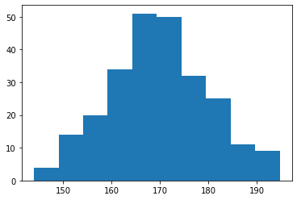

```python
import matplotlib.pyplot as plt
import numpy as np

x = np.random.normal(170, 10, 250)

plt.hist(x)
plt.show()
```

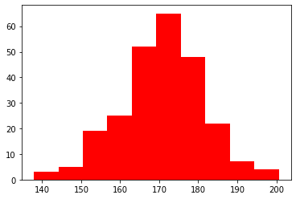

```python
import matplotlib.pyplot as plt
import numpy as np

x = np.random.normal(170, 10, 250)

plt.hist(x,color='red')
plt.show()
```

Example: Say you ask for the height of 250 people, you might end up with a histogram like this:

You can read from the histogram that there are approximately:

5 people from 145 to 150cm

53 people from 168 to 173cm